# Heart_Disease

Yewande Ogunbowale

2022-08-19

Importe cleveland data into R. and change column names

```r
Cleveland <- read.table("https://archive.ics.uci.edu/ml/machine-learning-databases/heart-disease/processed.cleveland.data", na.strings="?", sep = "," )
colnames(Cleveland) <- c("age","sex","cp","trestbps","chol","fbs","restecg","thalach","exang","oldpeak","slope","ca","thal","pred")


attach(Cleveland)
```

Data Exploration. This is the initial process of performing investigations on data so as to discover patterns, spot anomalies and check assumptions with the help of summary statistics and graphical representations

```r
library(DataExplorer)

#This gives a brief account(mean, median...) of the data
summary(Cleveland)
```

```
##       age             sex               cp           trestbps
##  Min.   :29.00   Min.   :0.0000   Min.   :1.000   Min.   : 94.0
##  1st Qu.:48.00   1st Qu.:0.0000   1st Qu.:3.000   1st Qu.:120.0
##  Median :56.00   Median :1.0000   Median :3.000   Median :130.0
##  Mean   :54.44   Mean   :0.6799   Mean   :3.158   Mean   :131.7
##  3rd Qu.:61.00   3rd Qu.:1.0000   3rd Qu.:4.000   3rd Qu.:140.0
##  Max.   :77.00   Max.   :1.0000   Max.   :4.000   Max.   :200.0
##
##       chol            fbs            restecg          thalach
##  Min.   :126.0   Min.   :0.0000   Min.   :0.0000   Min.   : 71.0
##  1st Qu.:211.0   1st Qu.:0.0000   1st Qu.:0.0000   1st Qu.:133.5
##  Median :241.0   Median :0.0000   Median :1.0000   Median :153.0
##  Mean   :246.7   Mean   :0.1485   Mean   :0.9901   Mean   :149.6
##  3rd Qu.:275.0   3rd Qu.:0.0000   3rd Qu.:2.0000   3rd Qu.:166.0
##  Max.   :564.0   Max.   :1.0000   Max.   :2.0000   Max.   :202.0
##
##      exang           oldpeak         slope             ca
##  Min.   :0.0000   Min.   :0.00   Min.   :1.000   Min.   :0.0000
##  1st Qu.:0.0000   1st Qu.:0.00   1st Qu.:1.000   1st Qu.:0.0000
##  Median :0.0000   Median :0.80   Median :2.000   Median :0.0000
##  Mean   :0.3267   Mean   :1.04   Mean   :1.601   Mean   :0.6722
##  3rd Qu.:1.0000   3rd Qu.:1.60   3rd Qu.:2.000   3rd Qu.:1.0000
##  Max.   :1.0000   Max.   :6.20   Max.   :3.000   Max.   :3.0000
##                                                  NA's   :4
##       thal            pred
##  Min.   :3.000   Min.   :0.0000
##  1st Qu.:3.000   1st Qu.:0.0000
##  Median :3.000   Median :0.0000
##  Mean   :4.734   Mean   :0.9373
##  3rd Qu.:7.000   3rd Qu.:2.0000
##  Max.   :7.000   Max.   :4.0000
##  NA's   :2
```

```r
#Head displays the first six data
head(Cleveland)
```

```
##   age sex cp trestbps chol fbs restecg thalach exang oldpeak slope ca thal pred
## 1  63   1  1      145  233   1       2     150     0     2.3     3  0    6    0
## 2  67   1  4      160  286   0       2     108     1     1.5     2  3    3    2
## 3  67   1  4      120  229   0       2     129     1     2.6     2  2    7    1
## 4  37   1  3      130  250   0       0     187     0     3.5     3  0    3    0
## 5  41   0  2      130  204   0       2     172     0     1.4     1  0    3    0
## 6  56   1  2      120  236   0       0     178     0     0.8     1  0    3    0
```

```r
#Tail shows the last six data
tail(Cleveland)
```

```
##     age sex cp trestbps chol fbs restecg thalach exang oldpeak slope ca thal
## 298  57   0  4      140  241   0       0     123     1     0.2     2  0    7
## 299  45   1  1      110  264   0       0     132     0     1.2     2  0    7
## 300  68   1  4      144  193   1       0     141     0     3.4     2  2    7
## 301  57   1  4      130  131   0       0     115     1     1.2     2  1    7
## 302  57   0  2      130  236   0       2     174     0     0.0     2  1    3
## 303  38   1  3      138  175   0       0     173     0     0.0     1 NA    3
##     pred
## 298    1
## 299    1
## 300    2
## 301    3
## 302    1
## 303    0
```

```r
str(Cleveland)
```

```
## 'data.frame':    303 obs. of  14 variables:
##  $ age     : num  63 67 67 37 41 56 62 57 63 53 ...
##  $ sex     : num  1 1 1 1 0 1 0 0 1 1 ...
##  $ cp      : num  1 4 4 3 2 2 4 4 4 4 ...
##  $ trestbps: num  145 160 120 130 130 120 140 120 130 140 ...
##  $ chol    : num  233 286 229 250 204 236 268 354 254 203 ...
##  $ fbs     : num  1 0 0 0 0 0 0 0 0 1 ...
##  $ restecg : num  2 2 2 0 2 0 2 0 2 2 ...
##  $ thalach : num  150 108 129 187 172 178 160 163 147 155 ...
##  $ exang   : num  0 1 1 0 0 0 0 1 0 1 ...
##  $ oldpeak : num  2.3 1.5 2.6 3.5 1.4 0.8 3.6 0.6 1.4 3.1 ...
##  $ slope   : num  3 2 2 3 1 1 3 1 2 3 ...
##  $ ca      : num  0 3 2 0 0 0 2 0 1 0 ...
##  $ thal    : num  6 3 7 3 3 3 3 3 7 7 ...
##  $ pred    : int  0 2 1 0 0 0 3 0 2 1 ...
```

```r
introduce(Cleveland)
```

```
##   rows columns discrete_columns continuous_columns all_missing_columns
## 1  303      14                0                 14                   0
##   total_missing_values complete_rows total_observations memory_usage
## 1                    6           297               4242        36336
```

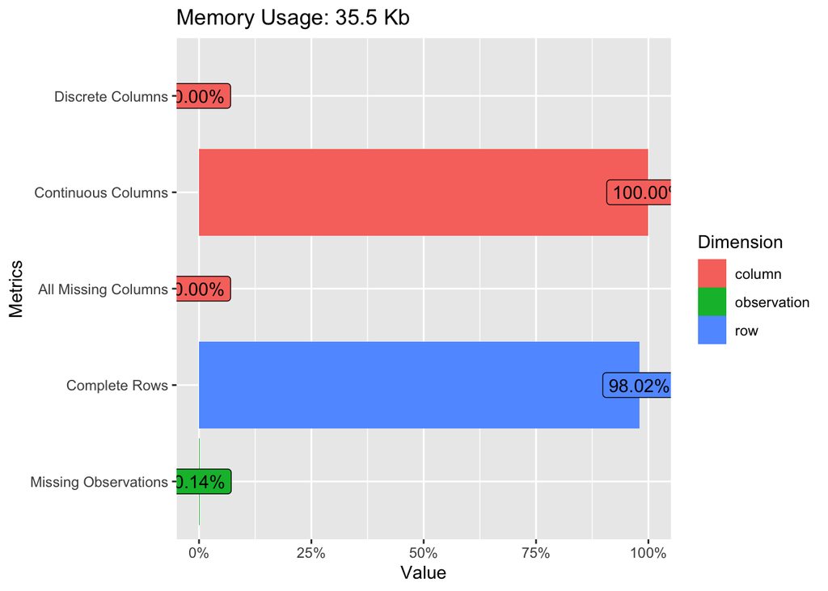

```r
plot_intro(Cleveland)
```

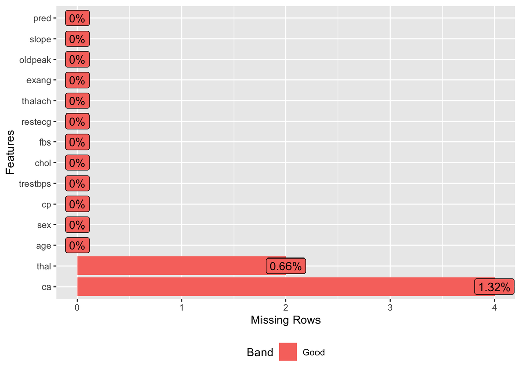

```r
#Missing data poses problem in every data. This function displays missing data in cleveland.
plot_missing(Cleveland)
```

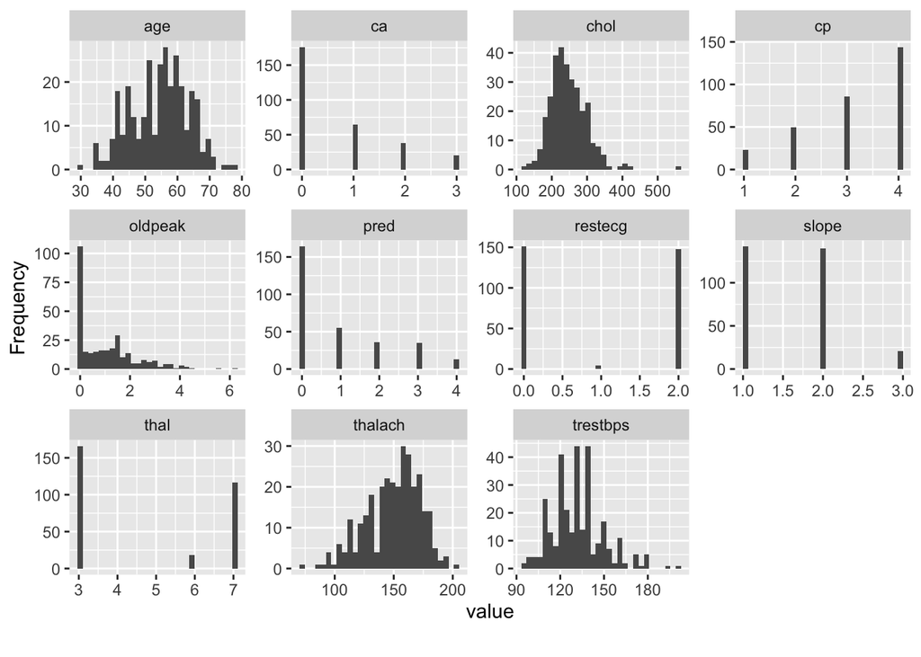

```r
plot_histogram(Cleveland)
```

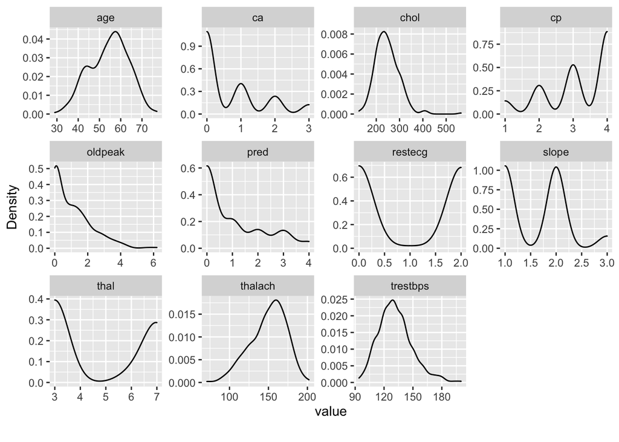

```r
plot_density(Cleveland)
```

Data explorer() displays the content of Cleveland data. There are 6 missing datas. 2 in thal and 4 ca. Missing data or Na.s if not taken care of might affect our conclusion negatively.

Data Cleaning

```r
anyNA(Cleveland)
```

```
## [1] TRUE
```

```r
#True means there are missing data in cleveland. Some cleaning up is there for needed.


sum(is.na(Cleveland))
```

```
## [1] 6
```

```r
#summed up all the missing data in my dataset.


colSums(is.na(Cleveland))
```

```
##      age      sex       cp trestbps     chol      fbs  restecg  thalach
##        0        0        0        0        0        0        0        0
##    exang  oldpeak    slope       ca     thal     pred
##        0        0        0        4        2        0
```

```r
#shows the location of the missing value.


Cleveland.new <- na.omit(Cleveland)
nrow(Cleveland.new)
```

```
## [1] 297
```

```r
#After cleaning, cleveland data reduced to 297 from 303 observations. Cleveland. new now has 297 observations.



Cleveland$thal[which(is.na(Cleveland$thal))]<- mean(Cleveland$thal,na.rm = TRUE)
Cleveland$ca[which(is.na(Cleveland$ca))]<- mean(Cleveland$ca,na.rm = TRUE)
anyNA(Cleveland)
```

```
## [1] FALSE
```

After replacing missing values in thal and ca with mean. I checked for Na’s and it returned False.

Normalization minimizes data redundancy(Repetiton of similar data in multiple places)

```r
normalize <- function(x) (x - min(x))/max(x)-min(x)
cleveland_norm <- as.data.frame(lapply(Cleveland.new[,c(1,4,5,8,10)],normalize))
cleveland_norm_scaled <- scale(cleveland_norm, center = TRUE, scale = TRUE)
str(cleveland_norm)
```

```
## 'data.frame':    297 obs. of  5 variables:
##  $ age     : num  -28.6 -28.5 -28.5 -28.9 -28.8 ...
##  $ trestbps: num  -93.7 -93.7 -93.9 -93.8 -93.8 ...
##  $ chol    : num  -126 -126 -126 -126 -126 ...
##  $ thalach : num  -70.6 -70.8 -70.7 -70.4 -70.5 ...
##  $ oldpeak : num  0.371 0.242 0.419 0.565 0.226 ...
```

```r
summary(cleveland_norm)
```

```
##       age            trestbps           chol           thalach
##  Min.   :-29.00   Min.   :-94.00   Min.   :-126.0   Min.   :-71.00
##  1st Qu.:-28.75   1st Qu.:-93.87   1st Qu.:-125.8   1st Qu.:-70.69
##  Median :-28.65   Median :-93.82   Median :-125.8   Median :-70.59
##  Mean   :-28.67   Mean   :-93.81   Mean   :-125.8   Mean   :-70.61
##  3rd Qu.:-28.58   3rd Qu.:-93.77   3rd Qu.:-125.7   3rd Qu.:-70.53
##  Max.   :-28.38   Max.   :-93.47   Max.   :-125.2   Max.   :-70.35
##     oldpeak
##  Min.   :0.0000
##  1st Qu.:0.0000
##  Median :0.1290
##  Mean   :0.1703
##  3rd Qu.:0.2581
##  Max.   :1.0000
```

```r
summary(cleveland_norm_scaled)
```

```
##       age             trestbps             chol             thalach
##  Min.   :-2.8224   Min.   :-2.12205   Min.   :-2.33377   Min.   :-3.4261
##  1st Qu.:-0.7229   1st Qu.:-0.65832   1st Qu.:-0.69907   1st Qu.:-0.7235
##  Median : 0.1611   Median :-0.09534   Median :-0.08366   Median : 0.1482
##  Mean   : 0.0000   Mean   : 0.00000   Mean   : 0.00000   Mean   : 0.0000
##  3rd Qu.: 0.7136   3rd Qu.: 0.46763   3rd Qu.: 0.55098   3rd Qu.: 0.7149
##  Max.   : 2.4816   Max.   : 3.84547   Max.   : 6.08970   Max.   : 2.2841
##     oldpeak
##  Min.   :-0.9052
##  1st Qu.:-0.9052
##  Median :-0.2192
##  Mean   : 0.0000
##  3rd Qu.: 0.4669
##  Max.   : 4.4116
```

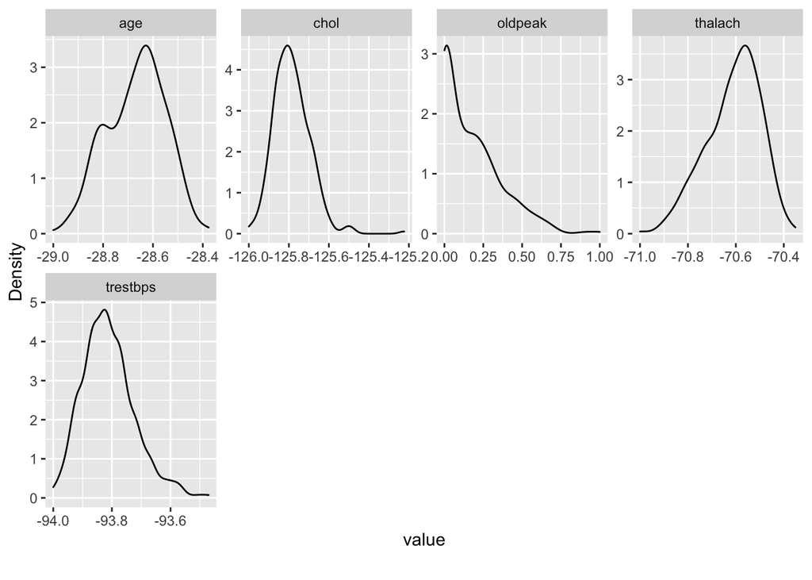

```r
plot_density(cleveland_norm)
```

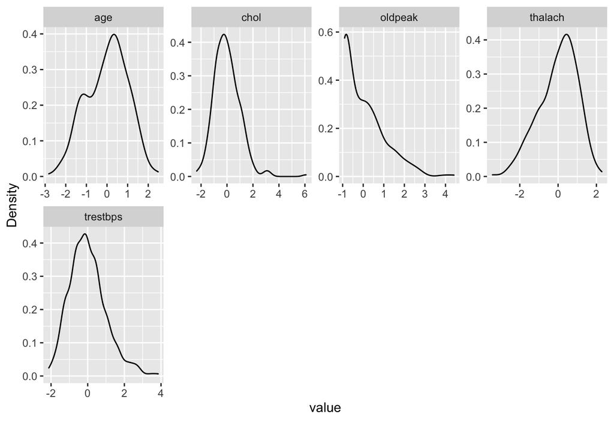

```r
plot_density(cleveland_norm_scaled)
```

Convertion of factor variable to dummy Variable. Transforms a categorical variable with more than two modalities in several dummy variables with only two modalities, Yes(=1) or No(0)

```r
library(caret)
```